# 당뇨병 발병 여부

- 당뇨병 발병을 예측하여라
- 피마 인디언은 1950년대까지 비만인 사람이 없는 민족이였는데 현재 60%가 당뇨, 80%가 비만으로 고통받고 있어 이 부족의 건강상태를 조사하려한다. 당뇨병이 있는지 없는지를 판단해 다음에 어떤 환자가 왔을때 당뇨 여부를 미리 예측하여라.

```python
# 주피터 노트북 환경설정
import warnings
warnings.filterwarnings('ignore')
warnings.simplefilter('ignore')

from IPython.display import set_matplotlib_formats
set_matplotlib_formats("retina")

from IPython.display import Image

from IPython.core.display import display, HTML
display(HTML("<style>.container { font-weight: bold !important; }</style>"))
display(HTML("<style>.container { width: 98% !important; }</style>"))
```

```python
import numpy as np
import pandas as pd
import matplotlib
import matplotlib.pyplot as plt
import seaborn as sns
%matplotlib inline
plt.rcParams['font.size'] = 12.0
plt.rcParams['font.family'] = 'Malgun Gothic'
matplotlib.rcParams['axes.unicode_minus'] = False
```

## Scaling

- 자료의 오버플로우(overflow)나 언더플로우(underflow) 방지
- 독립 변수의 공분산 행렬의 조건수(condition number)를 감소시켜 최적화 과정에서의 안정성 및 수렴 속도를 향상 시킨다.
- 조건수(condition number)? 작은 변화의 비율에 대해 함수가 얼마나 변화할 수 있는지 에 대한 argument measure

#### Scikit-Learn 스케일링의 종류

```
1   StandardScaler  기본 스케일. 평균과 표준편차 사용
2   MinMaxScaler    최대/최소값이 각각 1, 0이 되도록 스케일링
3   MaxAbsScaler    최대절대값과 0이 각각 1, 0이 되도록 스케일링
4   RobustScaler    중앙값(median)과 IQR(interquartile range) 사용.
                     아웃라이어의 영향을 최소화
```

```python
matrix = np.random.randint(-1000,1000,20).reshape(10,2)
data = pd.DataFrame(matrix)
# data
```

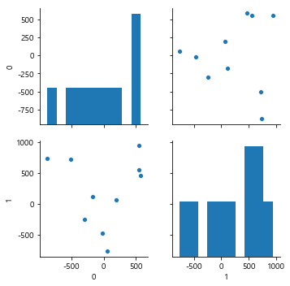

```python
sns.pairplot(data)
```

```python
# StandardScaler
from sklearn.preprocessing import StandardScaler
StandardScaler = StandardScaler()
StandardScaler.fit(matrix)
matrix = StandardScaler.transform(matrix)
# pd.DataFrame(matrix)
```

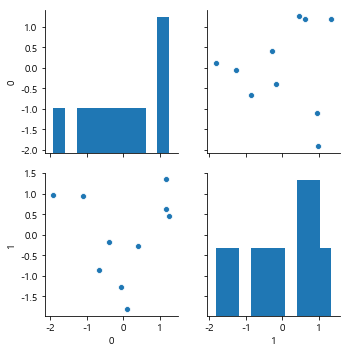

```python
sns.pairplot(pd.DataFrame(matrix))
```

```python
# MinMaxScaler
from sklearn.preprocessing import MinMaxScaler
MinMaxScaler = MinMaxScaler()
MinMaxScaler.fit(data)
data = MinMaxScaler.transform(data)
pd.DataFrame(data)
```

|  | 0 | 1 |
| --- | --- | --- |
| 0 | 0.254969 | 0.873174 |
| 1 | 0.733379 | 0.485096 |
| 2 | 0.587389 | 0.173583 |
| 3 | 0.000000 | 0.882525 |
| 4 | 0.394106 | 0.303331 |
| 5 | 0.481151 | 0.516072 |
| 6 | 0.977382 | 1.000000 |
| 7 | 0.642221 | 0.000000 |
| 8 | 1.000000 | 0.720631 |
| 9 | 0.978067 | 0.774985 |

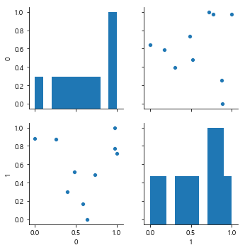

```python
sns.pairplot(pd.DataFrame(data))
```

```python
# MaxAbsScaler
from sklearn.preprocessing import MaxAbsScaler
MaxAbsScaler = MaxAbsScaler()
MaxAbsScaler.fit(data)
data = MaxAbsScaler.transform(data)
pd.DataFrame(data)
```

|  | 0 | 1 |
| --- | --- | --- |
| 0 | 0.254969 | 0.873174 |
| 1 | 0.733379 | 0.485096 |
| 2 | 0.587389 | 0.173583 |
| 3 | 0.000000 | 0.882525 |
| 4 | 0.394106 | 0.303331 |
| 5 | 0.481151 | 0.516072 |
| 6 | 0.977382 | 1.000000 |
| 7 | 0.642221 | 0.000000 |
| 8 | 1.000000 | 0.720631 |
| 9 | 0.978067 | 0.774985 |

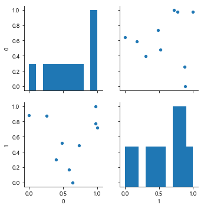

```python
sns.pairplot(pd.DataFrame(data))
```

```python
# RobustScaler
from sklearn.preprocessing import RobustScaler
RobustScaler = RobustScaler()
RobustScaler.fit(data)
data = RobustScaler.transform(data)
pd.DataFrame(data)
```

|  | 0 | 1 |
| --- | --- | --- |
| 0 | -0.718932 | 0.509792 |
| 1 | 0.236905 | -0.266589 |
| 2 | -0.054776 | -0.889798 |
| 3 | -1.228346 | 0.528500 |
| 4 | -0.440945 | -0.630225 |
| 5 | -0.267032 | -0.204619 |
| 6 | 0.724409 | 0.763519 |
| 7 | 0.054776 | -1.237065 |
| 8 | 0.769599 | 0.204619 |
| 9 | 0.725779 | 0.313359 |

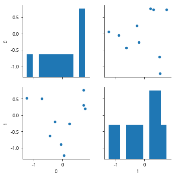

```python
sns.pairplot(pd.DataFrame(data))
```

# 머신러닝 과정

- 모듈 임포트
- 데이타 수집 (학습데이타)
- 데이타 전처리
- 데이터 학습 (모델화)
- 데이터 예측 (테스트데이타)
- 데이터 테스트 (정답률)

```python
# 학습기 모듈
from sklearn.neighbors import KNeighborsClassifier
from sklearn.tree import DecisionTreeClassifier
from sklearn.ensemble import RandomForestClassifier
from sklearn.naive_bayes import GaussianNB
from sklearn.svm import SVC
```

```python
from sklearn.metrics import accuracy_score
from sklearn import metrics
from sklearn.model_selection import train_test_split
```